# PM566 Midterm

Suyeon Ryu

2020 10 5

# **Comparison in U.S. Colon Cancer Rates between East Coast and West Coast**

# Introduction

Colorectal cancer was known to have low prevalence rates compared to other types of cancers in U.S. history. In the recent years, however, it was discussed that the proportion of colorectal cancer in U.S. populations has increased. More importantly and interestingly, the incidence and mortality are thought to be different from West Coast to East Coast with unknown causes. This paper will discuss and compare the incidence and mortality rates of colon cancers in U.S. population. Specifically, 3 states representing the West Coast are compared to 7 states representing the East Coast, through the data exploration analyses.

# Methods

## Data Sources

### Cancer Incidence / Mortality Data

Data on cancer incidences/mortalities during 1999 through 2017 were obtained from the United States Cancer Statistics(USCS) data provided by the Centers for Disease Control and Prevention’s National Center for Health Statistics(NCHS). As our focus is specifically colorectal cancers, all data for other cancers were omitted from the data set. Then, due to the limited computing power, the 1 in every 20 data was used to perform the data exploratory analysis using R version 3.6.0. Any outliers were assessed from the scatter-plot, and was computationally removed from the data set for the further analyses. No statistical computations were performed in this report.

### Selection of West Coast and East Coast

Based on the U.S. map, three reprensentative states that have coast line of Pacific ocean were chosen, which are California, Washington, and Oregon. With the same method, seven representative states that have coast line of Atlantic ocean were chosen, which are New York, Pennsylvania, NewJersey, Virginia, North and South Carolina, and Georgia. To diminish the possible bias coming from the latitutde, Florida was exlcuded.

### Demographic characteristics

The data were collected from all sex, racial/ethnic groups, and age(all ages from <1 to 85+). The data collected for Incidence data from NPCR and SEER registries in 49 states cover approximately 98% of U.S. Population. For Mortality data, 100% of U.S. population was covered. For purposes of brevity, in this report, only colon and rectum cancer related information is regarded.

```
## [1] 1999 2017
```

TABLE 1. U.S. Colon Cancer Incidence Rate History

| YEAR | Median Rate | S.D. | Mean |
| --- | --- | --- | --- |
| 1999 | 51 | 49.18 | 48.9 |
| 2000 | 43.8 | 46.8 | 44.82 |
| 2001 | 42.8 | 39.02 | 42.16 |
| 2002 | 37.1 | 44.4 | 41.21 |
| 2003 | 41.9 | 43.88 | 38.59 |
| 2004 | 38.8 | 37.5 | 37.39 |
| 2005 | 37.6 | 39 | 36.98 |
| 2006 | 33.5 | 29.37 | 32.31 |
| 2007 | 30.9 | 33.48 | 32.4 |
| 2008 | 28.9 | 33.67 | 32.43 |
| 2009 | 34.9 | 32.2 | 32.93 |
| 2010 | 39.3 | 19.8 | 35.6 |
| 2011 | 33.4 | 27 | 32.3 |
| 2012 | 34.2 | 25.78 | 33.05 |
| 2013 | 32.2 | 26.35 | 33.12 |
| 2014 | 32.5 | 28.62 | 33.89 |
| 2015 | 30.7 | 27.65 | 33.35 |
| 2016 | 40 | 26 | 37.31 |
| 2017 | 27.8 | 22.8 | 30.15 |

TABLE 2. U.S. Colon Cancer Mortality Rate History

| YEAR | Median Rate | S.D. | Mean |
| --- | --- | --- | --- |
| 1999 | 15.9 | 16.15 | 16.51 |
| 2000 | 17.5 | 17.42 | 18.35 |
| 2001 | 16.6 | 16.8 | 15.72 |
| 2002 | 12.1 | 14.25 | 14.09 |
| 2003 | 11.2 | 15.35 | 13.1 |
| 2004 | 12.8 | 15.07 | 12.95 |
| 2005 | 11.6 | 15.88 | 12.91 |
| 2006 | 14.8 | 15.27 | 14.38 |
| 2007 | 11.1 | 14.93 | 13.57 |
| 2008 | 14.3 | 13.6 | 15.64 |
| 2009 | 12.8 | 10.78 | 13.05 |
| 2010 | 14.5 | 13.55 | 13.61 |
| 2011 | 12.9 | 12.12 | 12.66 |
| 2012 | 13.5 | 10.8 | 13.5 |
| 2013 | 11.6 | 11.9 | 12.07 |
| 2014 | 9.6 | 11.8 | 10.25 |
| 2015 | 11.2 | 12.6 | 13.38 |
| 2016 | 11.9 | 11.75 | 13.27 |
| 2017 | 13.2 | 13.4 | 11.78 |

# Preliminary Results

## Colorectal Cancer Incidence and Mortality Rates and Trends

Overall, the trends in colorectal cancer incidence rate shows decreasing trend over the period of 18 years (1999 to 2017). The rate decreasing slope was steeper until the early 2000, then shows stablized trend from 2007 to 2017(Figure 1). Regardless, the overall mortality from colon cancer in U.S. maintained around same rate over 17 years, without showing particularly decreasing trends (Figure 2).

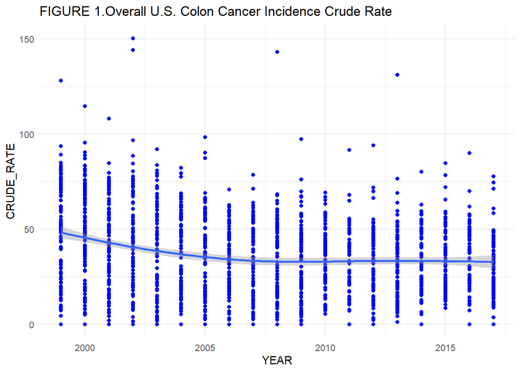

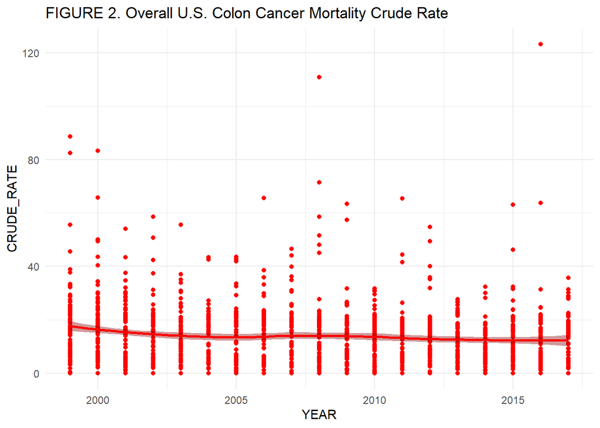

## Comparison of Colon Cancer **Incidence Rates** between EAST and WEST

### Colorectal Cancer Incidence **Crude** Rates

To ease the understanding of the geographical representation of each coast, the states which colon cancer data were collected from were highlighted (FIGURE 3). The bar graph of colorectal cancer incidence rates of each coast as well as the un-considered areas by year were plotted(FIGURE 4). Then, to aid the comparison of incidence rate over the years, the scatterplot of each coasts with regression lines were plotted (FIGURE 5). Based on the comparison scatterplot with regression lines, it is apparent that the incidence rates are decreasing over the years, but the rate of decreasing is slower for the West Coast compared to the East Coast.

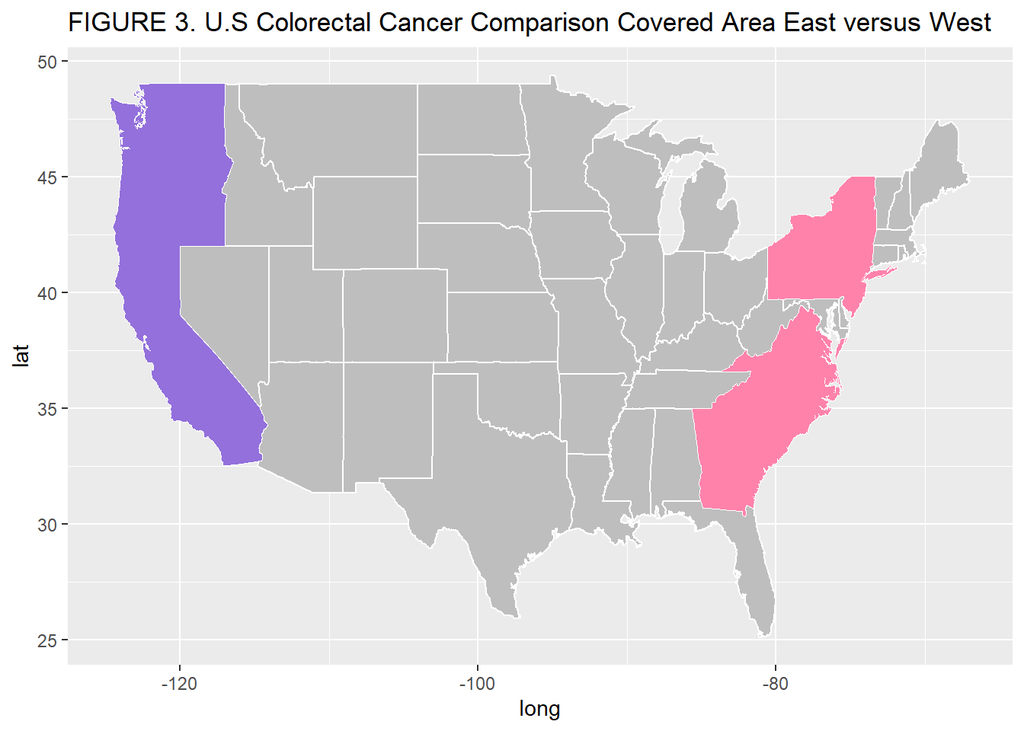

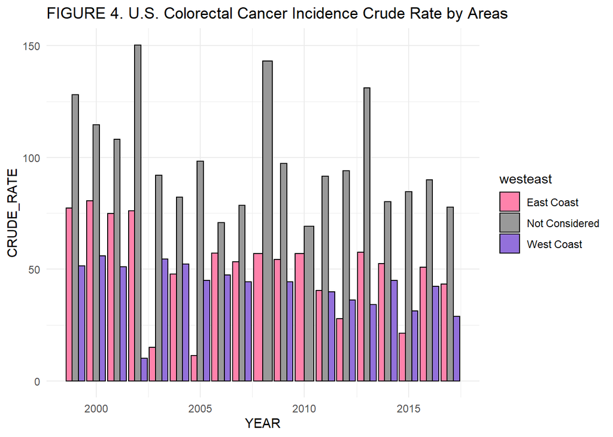

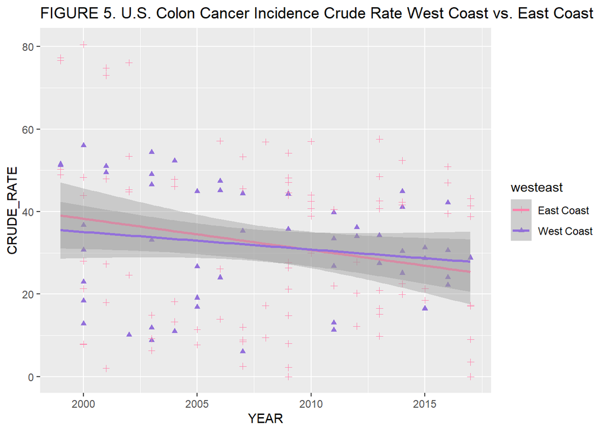